# LTE Data Analytics Case Study

Deon Jacobs

03 September 2016

# Synopsis

This case study provides a brief overview of the methodology and reproducibility of analysing an LTE network. Care has been taken not to divulge specific confidential methodologies and information regarding the MTN network.

Within a mobile operator environment, many data sources exist from various applications and databases. Different departments use these sources to do their analytics and apply their domain knowledge to answer particular questions related to: - Mobile network performance  
- User experience  
- Network capacity and coverage  
- Segmentation and usage behaviour

R-code is used to read, manipulate and merge these various data source output files into one consolidated source file for analysis in Tableau. More in-depth inferential statistical analysis is performed in R where required.

### Hypothetical Marketing Question to be answered

- Will upgrade of LTE carrier bandwith in specific mainplace clusters result in revenue growth?

# Data Sources of Interest

To answer this hypothetical question, four data source outputs will be used and combined into one tidy data file for further analysis.

1. LTE Performance Statistics
2. LTE Network Configuration
3. BTS geographical Data
4. LTE Device Penetration

# LTE Performance Statistics

R code reads, manipulates scheduled LTE performance statistics report from specific operator. Here basic performance metrics: data-volume and throughput are queried.

```r
  library(dplyr)
  #set path where files are located
  setwd("C:/Users/jacobs_d/Documents/Copy_folder/2016/Network Analytics")

  #input file names
  lteTrafficFile <- "LTE_daily_traffic_v2.csv"

  #read daily per cell LTE traffic from file
  lteRawTraffic <- read.csv(file.path("raw files",lteTrafficFile),skip=1,header = TRUE)

  #Rename collumn names
  colnames(lteRawTraffic)[1] <- "date"
  colnames(lteRawTraffic)[2] <- "cell"
  colnames(lteRawTraffic)[3] <- "mainplace"
  colnames(lteRawTraffic)[4] <- "siteid"
  colnames(lteRawTraffic)[5] <- "dl_datavol"
  colnames(lteRawTraffic)[6] <- "ul_datavol"
  colnames(lteRawTraffic)[7] <- "total_datavol"
  colnames(lteRawTraffic)[8] <- "bandwidth"
  colnames(lteRawTraffic)[9] <- "dl_throughput"
  colnames(lteRawTraffic)[10] <- "ul_throughput"

  #Convert date column to correct Data format
  lteRawTraffic$date <- as.Date(lteRawTraffic$date, "%Y-%m-%d")

  #Aggregated traffic up to site level for each day if required for r-analysis
  lteDailyTraffic <- lteRawTraffic %>%
                     group_by(date,mainplace) %>%
                     summarise(dl_datavol_sum = sum(dl_datavol,na.rm=TRUE),
                               ul_datavol_sum = sum(ul_datavol,na.rm=TRUE),
                               total_datavol_sum = sum(total_datavol,na.rm=TRUE),
                               bandwidth = mean(bandwidth,na.rm=TRUE),
                               dl_thrpt_avg = mean(dl_throughput,na.rm=TRUE),
                               ul_thrpt_avg = mean(ul_throughput,na.rm=TRUE)
                               )

  #Write dataset to file
  write.table(lteRawTraffic,file.path("script files","LTE_aggregated_daily_traffic.csv"),sep=",",row.names=FALSE)
  head(lteRawTraffic)
```

```
##         date     cell    mainplace siteid dl_datavol ul_datavol
## 1 2016-06-26 L08286B1 Johannesburg   8286       0.60       0.53
## 2 2016-06-26 L08286A1 Johannesburg   8286       0.02       0.03
## 3 2016-06-26 L08286C1 Johannesburg   8286       0.10       0.07
## 4 2016-06-26 L14698B1 Johannesburg  14698     888.27      93.79
## 5 2016-06-26 L14698C1 Johannesburg  14698    2131.85     239.74
## 6 2016-06-26 L14698A1 Johannesburg  14698     964.75     100.82
##   total_datavol bandwidth dl_throughput ul_throughput
## 1          1.13        10      27520.41      17290.32
## 2          0.05        10      36000.00       9000.00
## 3          0.17        10      36000.00        111.76
## 4        982.07         5       5408.51        411.16
## 5       2371.59         5       8401.35        726.52
## 6       1065.57         5       5693.37        451.07
```

# LTE Network Config

Three R code scripts are needed here:  
1. Consolidation of entire access technology (GSM, UMTS, LTE) configuration per radio base station (BTS).  
2. Merging of the per BTS configuration with geographical data to roll analysis up to marketing mainplace definition.  
3. Merging the configuration and geographical consolidation with previous LTE “cleaned” statistical performance data.

### Consolidated radio access technology configuration merged with geopgraphical data

```r
  library(dplyr)
  library(stringr)
  library(tidyr)
  library(lubridate)
  library(reshape)
  #library(ROracle)
  #con <- dbConnect(drv,"huawei_gsm","password$",dbname='stats')

  #set path where files are located
  setwd("C:/Users/jacobs_d/Documents/Copy_folder/2016/Network Analytics")

  #input file names
  gsmFile <- "TRX_COUNT_2G.csv"
  wcdmaFile <- "UMTS_UARFCN.csv"
  lteFile <- "LTE_BW_ALL.csv"
  locationFile <- "Site_location_data_cluster.csv"

  #Load site location data
  siteLocation <-read.csv(file.path("raw files",locationFile),header = TRUE)

  names(siteLocation) <- tolower(names(siteLocation))

  ##########################################################################################
  ##LTE data manipulation
  ##########################################################################################
  #Load LTE BW config per cell
  lteConfig <- read.csv(file.path("raw files",lteFile),header = TRUE)

  #Generate Site column from file
  newLteConfig <- separate(lteConfig,"CELLNAME", c("l","siteid","sector","num"),sep=c(1,6,7),convert=TRUE,remove=FALSE) %>%
                  filter(l=="L" & EARFCNDL <= 1377 & EARFCNDL != 350) %>%
                  select(-l,-num)
  newLteConfig$CELLNAME <- as.character(newLteConfig$CELLNAME)
  #Generate cellid column from LTE config dataframe
  newLteConfig$siteid <-as.character(as.numeric(newLteConfig$siteid))
  lteConf.s <- mutate(newLteConfig,cell = paste0(siteid,sector)) %>%
               select(-sector) %>%
               mutate(lte_sector = substr(CELLNAME,1,nchar(CELLNAME)-1)) %>%
               select(-CELLNAME,-ULBANDWIDTH,-EARFCNUL) %>%
               select(lte_sector,siteid:cell)

  lteConf.s$siteid <-as.numeric(lteConf.s$siteid)

  #change variable names to lower case
  names(lteConf.s) <- tolower(names(lteConf.s))

  #Pivot earfcn colum
  lteConf.s <- spread(lteConf.s, key=earfcndl, value=dlbandwidth)


  colnames(lteConf.s)[7] <- "l_1800_3_5_10"
  colnames(lteConf.s)[6] <- "l_2100_5"
  colnames(lteConf.s)[5] <- "l_2100_15"

  #Split LTE 1800 bandwidth assignments per column
  lteConf.sp <- spread(lteConf.s,key=l_1800_3_5_10, value=l_1800_3_5_10)

  colnames(lteConf.sp)[7] <- "l_1800_3"
  colnames(lteConf.sp)[8] <- "l_1800_5"
  colnames(lteConf.sp)[9] <- "l_1800_10"

  lteConf.sp$l_2100_5[lteConf.sp$l_2100_5=="5000"] <- "1"
  lteConf.sp$l_2100_15[lteConf.sp$l_2100_15=="15000"] <- "1"
  lteConf.sp$l_1800_3[lteConf.sp$l_1800_3=="3000"] <- "1"
  lteConf.sp$l_1800_5[lteConf.sp$l_1800_5=="5000"] <- "1"
  lteConf.sp$l_1800_10[lteConf.sp$l_1800_10=="10000"] <- "1"

  lteConf.sp$l_2100_5 <-as.numeric(lteConf.sp$l_2100_5)
  lteConf.sp$l_2100_15 <-as.numeric(lteConf.sp$l_2100_15)
  lteConf.sp$l_1800_3 <-as.numeric(lteConf.sp$l_1800_3)
  lteConf.sp$l_1800_5 <-as.numeric(lteConf.sp$l_1800_5)
  lteConf.sp$l_1800_10 <-as.numeric(lteConf.sp$l_1800_10)

  ###########################################################################################
  ##UMTS data manipulation
  ###########################################################################################
  #Load UMTS config per cell
  umtsConfig <- read.csv(file.path("raw files",wcdmaFile),header = TRUE)

  newUmtsConfig <- separate(umtsConfig,"CELLNAME",c("siteid","sector"),sep="A|B|C|D|E|F|G|H|I|J|K|L|M|N|O|P|Q",remove=FALSE,extra="merge",fill="right") %>%
                   select(-sector,-UARFCNUL)
  newUmtsConfig$siteid <- as.numeric(newUmtsConfig$siteid)
  names(newUmtsConfig)[names(newUmtsConfig)=="CELLNAME"] <- "cellid"
  names(newUmtsConfig)[names(newUmtsConfig)=="UARFCNDL"] <- "carrier"
  names(newUmtsConfig) <- tolower(names(newUmtsConfig))
  newUmtsConfig$cellid <- as.character(newUmtsConfig$cellid)
  umtsConf.s <- mutate(newUmtsConfig,cell= substr(cellid,1,nchar(cellid)-1)) %>%
                select(-cellid)
  #Pivot carrier column to have column view of each carrier assignment per sector
  umtsConf.s <- spread(umtsConf.s, key=carrier, value=carrier)

  colnames(umtsConf.s)[5] <- "u_3086"
  colnames(umtsConf.s)[6] <- "u_10712"
  colnames(umtsConf.s)[7] <- "u_10737"
  colnames(umtsConf.s)[8] <- "u_10762"
  umtsConf.s$u_3086[umtsConf.s$u_3086=="3086"] <- "1"
  umtsConf.s$u_10762[umtsConf.s$u_10762=="10762"] <- "1"
  umtsConf.s$u_10737[umtsConf.s$u_10737=="10737"] <- "1"
  umtsConf.s$u_10712[umtsConf.s$u_10712=="10712"] <- "1"

  umtsConf.s$u_3086 <-as.numeric(umtsConf.s$u_3086)
  umtsConf.s$u_10712 <-as.numeric(umtsConf.s$u_10712)
  umtsConf.s$u_10737 <-as.numeric(umtsConf.s$u_10737)
  umtsConf.s$u_10762 <-as.numeric(umtsConf.s$u_10762)


  ############################################################################################
  ##GSM data manipulation
  ############################################################################################
  gsmConfig <- read.csv(file.path("raw files",gsmFile),header = TRUE)
  gsmConf.st <- spread(gsmConfig,key=BAND, value=TRXCNT, convert=FALSE)
  names(gsmConf.st)[names(gsmConf.st)==""] <- "remove"

  gsmConf.s <- select(gsmConf.st,-remove)

  gsmConf.s$GSM1800[is.na(gsmConf.s$GSM1800)] <- 0
  gsmConf.s$GSM900[is.na(gsmConf.s$GSM900)] <- 0

  names(gsmConf.s) <- tolower(names(gsmConf.s))
  colnames(gsmConf.s)[2] <- "sector"
  colnames(gsmConf.s)[5] <- "g_900_trx_cnt"
  colnames(gsmConf.s)[4] <- "g_1800_trx_cnt"
  #generate siteid column in GSM database
  gsmConf.f <- separate(gsmConf.s,"sector",c("siteid","s"),sep="A|B|C|D|E|F|G|H|I|J|K|L|M|N|O|P|Q",remove=FALSE,extra="merge",fill="right") %>%
               select(-s)
  gsmConf.f$siteid <-as.numeric(gsmConf.f$siteid)

  ############################################################################################
  ##Generate a concatenated sector database between 3G and LTE
  ############################################################################################
  join3g4g <- full_join(umtsConf.s, lteConf.sp, by=c("siteid","cell","vendor"))
  names(join3g4g)[names(join3g4g)=="cell"] <- "sector"

  ############################################################################################
  ##Generate a concatenated sector database between LTE and 3G and 2G
  ############################################################################################
  sector2g3g4g <- full_join(join3g4g, gsmConf.f, by=c("siteid","sector","vendor"))

  sector2g3g4g$l_1800_3[is.na(sector2g3g4g$l_1800_3)] <- 0
  sector2g3g4g$l_1800_5[is.na(sector2g3g4g$l_1800_5)] <- 0
  sector2g3g4g$l_1800_10[is.na(sector2g3g4g$l_1800_10)] <- 0
  sector2g3g4g$l_2100_5[is.na(sector2g3g4g$l_2100_5)] <- 0
  sector2g3g4g$l_2100_15[is.na(sector2g3g4g$l_2100_15)] <- 0
  sector2g3g4g$u_3086[is.na(sector2g3g4g$u_3086)] <- 0
  sector2g3g4g$u_10712[is.na(sector2g3g4g$u_10712)] <- 0
  sector2g3g4g$u_10737[is.na(sector2g3g4g$u_10737)] <- 0
  sector2g3g4g$u_10762[is.na(sector2g3g4g$u_10762)] <- 0
  sector2g3g4g$g_1800_trx_cnt[is.na(sector2g3g4g$g_1800_trx_cnt)] <- 0
  sector2g3g4g$g_900_trx_cnt[is.na(sector2g3g4g$g_900_trx_cnt)] <- 0

  ############################################################################################
  ## Generate site LTE, 3G, and 2G radio database
  ############################################################################################
  site2g3g4g <- group_by(sector2g3g4g,siteid,vendor) %>%
                summarise(u_3086_sum = sum(u_3086),u_10712_sum = sum(u_10712),
                          u_10737_sum = sum(u_10737), u_10762_sum = sum(u_10762),
                          l_2100_15_sum = sum(l_2100_15), l_2100_5_sum = sum(l_2100_5),
                          l_1800_3_sum = sum(l_1800_3), l_1800_5_sum = sum(l_1800_5), l_1800_10_sum = sum(l_1800_10),
                          g_1800_trx_sum = sum(g_1800_trx_cnt),g_900_trx_sum = sum(g_900_trx_cnt))

  ############################################################################################
  ##Generate a concatenated sector coordinate radio database file
  ############################################################################################
  sectorDBlocation <- left_join(sector2g3g4g,siteLocation, by=c("siteid"))

  ############################################################################################
  ##Generate a concatenated site coordinate radio database file
  ############################################################################################
  siteDBlocation <- left_join(site2g3g4g,siteLocation, by=c("siteid"))

  #store sector database
  write.table(sectorDBlocation,file.path("script files","GSM_UMTS_LTE_Sector_Data.csv"),sep=",",row.names=FALSE)
  #store site database
  write.table(siteDBlocation,file.path("script files","GSM_UMTS_LTE_Site_Data.csv"),sep=",",row.names=FALSE)

  head(siteDBlocation)
```

```
## Source: local data frame [6 x 17]
## Groups: siteid [6]
##
##   siteid   vendor u_3086_sum u_10712_sum u_10737_sum u_10762_sum
##    (dbl)    (chr)      (dbl)       (dbl)       (dbl)       (dbl)
## 1   1.00 ERICSSON          3           3           3           3
## 2   1.24   HUAWEI          0           1           1           1
## 3   1.28   HUAWEI          0           1           1           1
## 4   1.30   HUAWEI          0           1           1           0
## 5   1.96   HUAWEI          0           1           1           0
## 6   2.00 ERICSSON          3           3           3           0
## Variables not shown: l_2100_15_sum (dbl), l_2100_5_sum (dbl), l_1800_3_sum
##   (dbl), l_1800_5_sum (dbl), l_1800_10_sum (dbl), g_1800_trx_sum (dbl),
##   g_900_trx_sum (dbl), sitename (fctr), pdeclon (dbl), pdeclat (dbl),
##   cluster_name (fctr)
```

### Merge Network Configuration Data with LTE Performance Statistical Data

```r
  library(dplyr)
  library(tidyr)
  setwd("C:/Users/jacobs_d/Documents/Copy_folder/2016/Network Analytics")
  siteConfig <- "GSM_UMTS_LTE_Site_Data.csv"

  #########################################################################################################
  ##Network configuration read and merge with LTE traffic
  #########################################################################################################

  #Read network config file from the correct sub folder
  networkConfig <- read.csv(file.path("script files",siteConfig),header = TRUE)

  #Do right outer joint with network configuration
  lteTrafficNetwork <- merge(x=networkConfig,y=lteRawTraffic,by="siteid",all.y=TRUE)

  #Drop columns of network config for UMTS and GSM as not related UMTS analysis
  lteTrafficNetwork <- select(lteTrafficNetwork, -u_3086_sum,-u_10712_sum,-u_10737_sum,-u_10762_sum,-g_1800_trx_sum,-g_900_trx_sum)

  #Clean up Bandwidth values
  lteTrafficNetwork <- lteTrafficNetwork %>%
                       mutate(BW = ifelse(bandwidth < 3, 0,
                                          ifelse(bandwidth >= 3 & bandwidth < 5, 3,
                                                 ifelse(bandwidth >=5 & bandwidth < 10,5,
                                                        ifelse(bandwidth >=10 & bandwidth < 15,10,
                                                               ifelse(bandwidth >=15 & bandwidth < 20,15,20)))))) %>%
                       select(-bandwidth)

  head(lteTrafficNetwork)
```

```
##   siteid   vendor l_2100_15_sum l_2100_5_sum l_1800_3_sum l_1800_5_sum
## 1      1 ERICSSON             0            0            0            3
## 2      1 ERICSSON             0            0            0            3
## 3      1 ERICSSON             0            0            0            3
## 4      1 ERICSSON             0            0            0            3
## 5      1 ERICSSON             0            0            0            3
## 6      1 ERICSSON             0            0            0            3
##   l_1800_10_sum  sitename  pdeclon   pdeclat cluster_name       date
## 1             0 IGI House 28.05135 -26.20722  Jhb Central 2016-06-24
## 2             0 IGI House 28.05135 -26.20722  Jhb Central 2016-07-26
## 3             0 IGI House 28.05135 -26.20722  Jhb Central 2016-07-05
## 4             0 IGI House 28.05135 -26.20722  Jhb Central 2016-08-18
## 5             0 IGI House 28.05135 -26.20722  Jhb Central 2016-08-18
## 6             0 IGI House 28.05135 -26.20722  Jhb Central 2016-06-27
##       cell    mainplace dl_datavol ul_datavol total_datavol dl_throughput
## 1 L00001C1 Johannesburg    2520.42     356.84       2877.25       5369.40
## 2 L00001C1 Johannesburg    6053.19     819.56       6872.75       5839.96
## 3 L00001A1 Johannesburg   23540.81    2672.83      26213.63       2294.88
## 4 L00001B1 Johannesburg    3855.75     475.67       4331.42       5533.01
## 5 L00001C1 Johannesburg    4787.62     805.59       5593.21       6151.83
## 6 L00001C1 Johannesburg    4010.55     421.95       4432.50       4414.17
##   ul_throughput BW
## 1        179.82  5
## 2       2088.64  5
## 3        107.59  5
## 4        431.45  5
## 5       1918.60  5
## 6        384.44  5
```

# Device Penetration Data

The final step is to merge the LTE device pentration data source output file to the consolidated data set from above.

```r
  library(dplyr)
  library(tidyr)
  setwd("C:/Users/jacobs_d/Documents/Copy_folder/2016/Network Analytics")
  deviceData <- "Most_cell_device_data.csv"

  #########################################################################################################
  ##Device Report merge with LTE traffic and network configuration to produce final csv file for tableau
  #########################################################################################################

  #read daily per cell LTE traffic from file
  deviceAnalysis <- read.csv(file.path("raw files",deviceData),header = TRUE)

  #change variable names to lower case
  names(deviceAnalysis) <- tolower(names(deviceAnalysis))

  #merge lte traffic and network combined data frame with device analysis data (right outer join)
  combinedLTE <- merge(x=deviceAnalysis,y=lteTrafficNetwork,by="siteid",all.y=TRUE)

  #Write csv file with config to appropriate folder
  write.table(combinedLTE,file.path("script files","LTE_daily_traffic_with_Network_config.csv"),sep=",",row.names=FALSE)

  head(combinedLTE$BW)
```

```
## [1] 5 5 5 5 5 5
```

# Inferential Analysis in R and Tableau to Answer Marketing Question

To answer the marketing question, a Tableau dashboard is developed from the consolidated file generated by r-scripts. These scripts can be automated, and consolidated data stored as files or within required database. This methodology ensures this investigation is reproducible and exactly documented. The consolidated data can be utilised for further trending as a sufficient historical set is achieved.

Inferential statistics are performed in R to test certain hypothesis in order to answer the question whether the LTE bandwidth upgrade can, in fact, increase revenue:

### Exploratory analysis by histogram

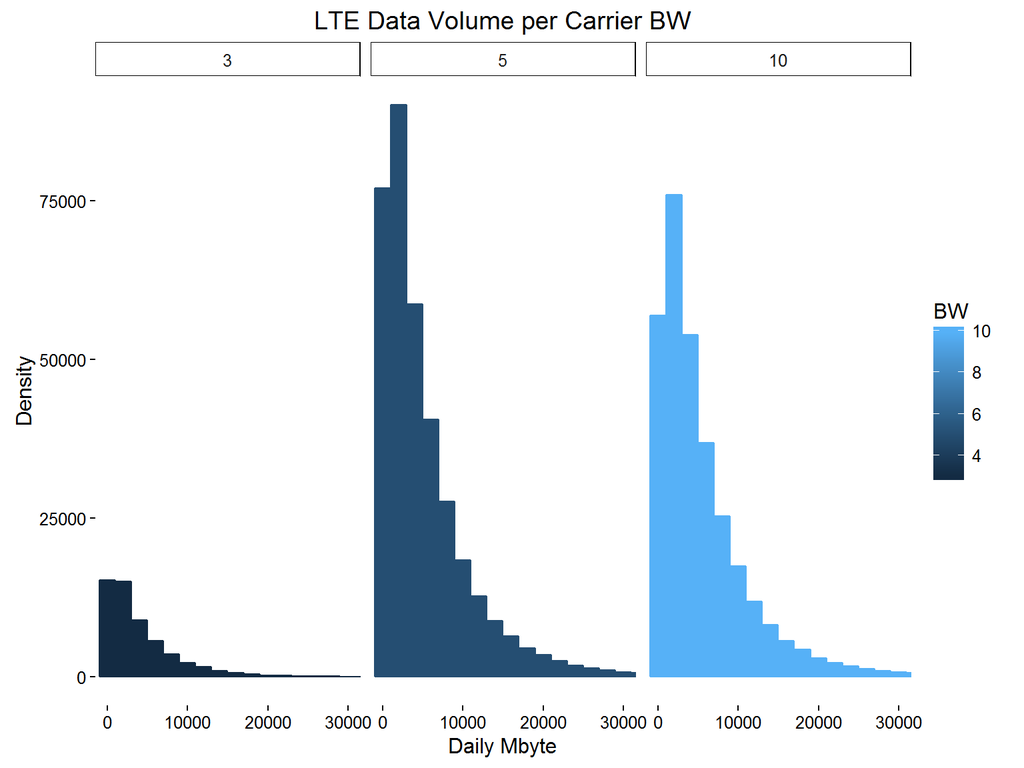

```r
library(ggplot2)
library(dplyr)
#Subset data for only 3,5,10 LTE carrier bandwidths, since most are configured on these three combinations
subLTE <- combinedLTE[which(combinedLTE$BW >= 3 & combinedLTE$BW < 15), ]
#Generate plot to show density histogram for the three LTE Carrier Bandwidths
ggplot(subLTE, aes(x=total_datavol, color=BW, fill=BW)) +
geom_histogram(binwidth=2000) +
coord_cartesian(xlim = c(0, 30000)) +
facet_grid(.~ BW) + theme_classic() +
labs(title="LTE Data Volume per Carrier BW",x="Daily Mbyte", y = "Density")
```

### Mean of Datavolume for each of the LTE Carrier Bandwidths:

```
## Source: local data frame [3 x 2]
##
##      BW datVolMean
##   (dbl)      (dbl)
## 1     3   4107.084
## 2     5   5324.833
## 3    10   5693.427
```

### Test Null Hypothesis that bandwidth upgrade will improve revenue (data volume)

Utilise the t-test function to calculate the 95% confidence interval. It is assumed that the data set follows a normal distribution, and the mean random variable over many simulations exhibits a constant variance.

From the histogram, the t-test will be performed between 5MHz and 10MHz LTE carrier bandwidth exhibiting highest percentage samples as independent groups.

```r
sub.ttest <- subset(subLTE,subLTE$BW %in% c(5,10))
t.test(total_datavol~BW,data=sub.ttest)
```

```
##
##  Welch Two Sample t-test
##
## data:  total_datavol by BW
## t = -23.521, df = 639940, p-value < 2.2e-16
## alternative hypothesis: true difference in means is not equal to 0
## 95 percent confidence interval:
##  -399.3081 -337.8798
## sample estimates:
##  mean in group 5 mean in group 10
##         5324.833         5693.427
```

# Conclusion

- Since the 95% confidence interval between the 5 and 10 MHz LTE carrier does not contain zero, and the p-value (probability of alternative to Null Hypothesis) is minute, its safe to say that revenue will increase with an increase in LTE BW.
- Tableau dashboard can now be utilised to understand where the best mainplace cluster would be to increase the LTE bandwidth from 5 to 10MHz.